# Seurat <-> SingleCellExperiment: Bioconductor Interoperability

## Introduction

Many Bioconductor workflows – scran normalization, scater QC, slingshot trajectory inference, MAST differential expression – operate on the [SingleCellExperiment](https://bioconductor.org/packages/SingleCellExperiment/) (SCE) container. Seurat provides built-in converters (`as.SingleCellExperiment()` and `as.Seurat()`) that move data between ecosystems. scConvert extends this by letting you route SCE objects directly to h5ad, h5Seurat, Loom, or Zarr via its hub architecture – no manual intermediate step required.

This article walks through the full workflow on the PBMC 3k dataset.

## 1 Load real PBMC3k data

```r
t0      <- proc.time()
pbmc    <- readH5AD("../pbmc3k.h5ad", verbose = FALSE)
elapsed <- (proc.time() - t0)[["elapsed"]]
cat(sprintf("Loaded: %d cells x %d genes in %.2fs\n",
            ncol(pbmc), nrow(pbmc), elapsed))
```

```
#> Loaded: 2638 cells x 13714 genes in 1.25s
```

## 2 Seurat analysis pipeline

```r
set.seed(42L)
pbmc <- NormalizeData(pbmc, verbose = FALSE)
pbmc <- FindVariableFeatures(pbmc, nfeatures = 2000L, verbose = FALSE)
pbmc <- ScaleData(pbmc, verbose = FALSE)
pbmc <- RunPCA(pbmc, npcs = 30L, verbose = FALSE)
pbmc <- RunUMAP(pbmc, dims = 1:20, verbose = FALSE)
pbmc <- FindNeighbors(pbmc, dims = 1:20, verbose = FALSE)
pbmc <- FindClusters(pbmc, resolution = 0.5, verbose = FALSE)
```

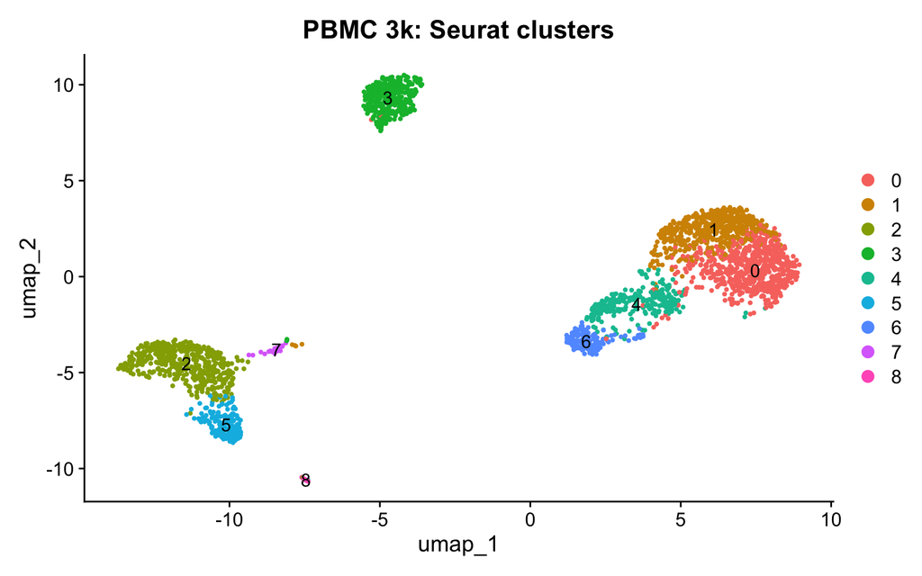

PBMC 3k UMAP coloured by Seurat clusters.

```r
DimPlot(pbmc, reduction = "umap", label = TRUE, label.size = 4) +
  ggtitle("PBMC 3k: Seurat clusters") +
  theme(plot.title = element_text(hjust = 0.5))
```

## 3 Seurat to SingleCellExperiment

`as.SingleCellExperiment()` transfers counts, normalized data, dimensional reductions, and cell metadata into the SCE container.

```r
suppressPackageStartupMessages(library(SingleCellExperiment))

sce <- as.SingleCellExperiment(pbmc)
cat(sprintf("SCE assays: %s\n",
            paste(assayNames(sce), collapse = ", ")))
```

```
#> SCE assays: counts, logcounts
```

```r
cat(sprintf("Reduced dims: %s\n",
            paste(reducedDimNames(sce), collapse = ", ")))
```

```
#> Reduced dims: PCA, UMAP
```

```r
cat(sprintf("colData columns: %d\n", ncol(colData(sce))))
```

```
#> colData columns: 8
```

## 4 Bioconductor QC workflow on SCE

A typical Bioconductor entry point is computing per-cell QC metrics. Below we use base R to calculate log-library-size and detected-feature counts – the same quantities that `scater::perCellQCMetrics()` would produce. The new columns become available to any SCE-aware tool.

```r
counts_mat <- assay(sce, "counts")
colData(sce)$log_library_size  <- log1p(Matrix::colSums(counts_mat))
colData(sce)$detected_features <- Matrix::colSums(counts_mat > 0)
cat(sprintf("Added QC columns: log_library_size, detected_features\n"))
```

```
#> Added QC columns: log_library_size, detected_features
```

```r
cat(sprintf("Median library size (log1p): %.2f\n",
            median(colData(sce)$log_library_size)))
```

```
#> Median library size (log1p): 7.70
```

```r
cat(sprintf("Median detected features: %.0f\n",
            median(colData(sce)$detected_features)))
```

```
#> Median detected features: 819
```

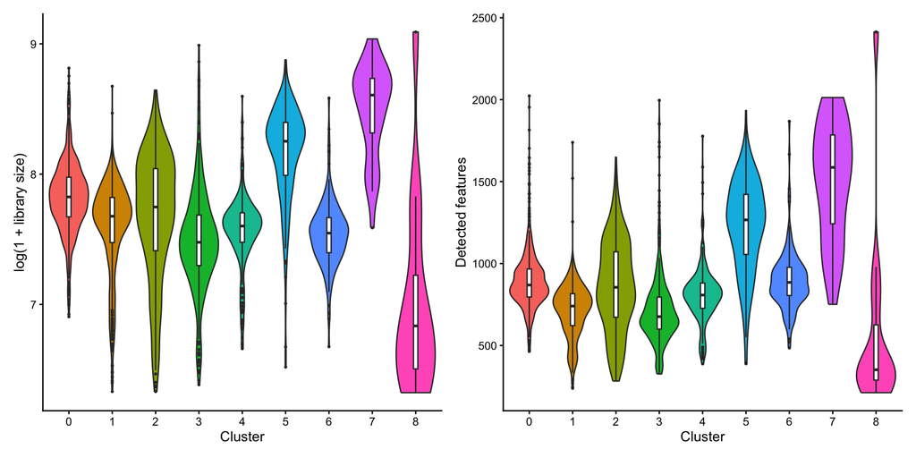

Per-cell QC metrics across Seurat clusters.

```r
qc_df <- data.frame(
  cluster         = as.character(pbmc$seurat_clusters),
  log_library     = colData(sce)$log_library_size,
  detected        = colData(sce)$detected_features
)

p1 <- ggplot(qc_df, aes(x = cluster, y = log_library, fill = cluster)) +
  geom_violin(scale = "width", trim = TRUE) +
  geom_boxplot(width = 0.1, outlier.size = 0.5, fill = "white") +
  labs(x = "Cluster", y = "log(1 + library size)") +
  theme_classic() +
  theme(legend.position = "none",
        axis.text.x = element_text(size = 9))

p2 <- ggplot(qc_df, aes(x = cluster, y = detected, fill = cluster)) +
  geom_violin(scale = "width", trim = TRUE) +
  geom_boxplot(width = 0.1, outlier.size = 0.5, fill = "white") +
  labs(x = "Cluster", y = "Detected features") +
  theme_classic() +
  theme(legend.position = "none",
        axis.text.x = element_text(size = 9))

suppressPackageStartupMessages(library(patchwork))
p1 + p2
```

## 5 SCE back to Seurat

`as.Seurat()` reconstructs the Seurat object from SCE. The `counts` and `data` arguments map SCE assay names to the appropriate Seurat layers. Any columns added to `colData` during the Bioconductor workflow travel with the object.

```r
seurat_rt <- as.Seurat(sce, counts = "counts", data = "logcounts")
cat(sprintf("Converted back: %d cells\n", ncol(seurat_rt)))
```

```
#> Converted back: 2638 cells
```

```r
cat(sprintf("Metadata columns: %s\n",
            paste(head(colnames(seurat_rt[[]]), 6L), collapse = ", ")))
```

```
#> Metadata columns: orig.ident, nCount_RNA, nFeature_RNA, seurat_annotations, percent.mt, RNA_snn_res.0.5
```

## 6 SCE to h5ad via scConvert

To share an SCE dataset with Python collaborators, pass it directly to `scConvert()`. The SCE is converted to a Seurat object internally, then written to the target format – no manual intermediate step is needed.

```r
h5ad_path <- file.path(tempdir(), "pbmc3k_sce.h5ad")

t0      <- proc.time()
scConvert(sce, dest = h5ad_path, overwrite = TRUE)
elapsed <- (proc.time() - t0)[["elapsed"]]

cat(sprintf("h5ad size: %.1f MB (%.2fs)\n",
            file.size(h5ad_path) / 1e6, elapsed))
```

```
#> h5ad size: 12.9 MB (0.65s)
```

## 7 What is preserved

### Seurat -> SCE -> Seurat round-trip

| Component | Preserved |
| --- | --- |
| Count matrix | Yes |
| Normalized data | Yes |
| Cell metadata | Yes |
| Gene metadata | Yes |
| PCA / UMAP | Yes (as reducedDims) |
| Neighbor graphs | Partial |

### Common Bioconductor workflows enabled by scConvert

| Workflow | Package | After scConvert |
| --- | --- | --- |
| QC filtering | scater | `perCellQCMetrics()` on SCE |
| Normalization | scran | `computeSumFactors()` on SCE |
| Trajectory | slingshot | `slingshot(sce, ...)` |
| Differential expression | MAST | `zlm(~ condition, sce)` |

## 8 Cleanup

```r
unlink(h5ad_path)
```